# Risk Factor Analysis

## Outcome Variable

**Outcome Variable:** haz

## Predictor Variables

**Intervention Variable:** hhwealth_quart

**Adjustment Set:**

- arm
- sex
- W_mage
- meducyrs
- feducyrs
- W_gagebrth
- W_birthwt
- W_birthlen
- W_nchldlt5
- W_parity
- delta_W_mage
- delta_meducyrs
- delta_feducyrs
- delta_W_gagebrth
- delta_W_birthwt
- delta_W_birthlen
- delta_W_nchldlt5
- delta_W_parity

## Stratifying Variables

The analysis was stratified on these variable(s):

- agecat
- studyid
- country

## Data Summary

| agecat | studyid | country | hhwealth_quart | n_cell | n |
| --- | --- | --- | --- | --- | --- |
| Birth | ki0047075b-MAL-ED | BANGLADESH | Wealth Q4 | 56 | 213 |
| Birth | ki0047075b-MAL-ED | BANGLADESH | Wealth Q1 | 52 | 213 |
| Birth | ki0047075b-MAL-ED | BANGLADESH | Wealth Q2 | 51 | 213 |
| Birth | ki0047075b-MAL-ED | BANGLADESH | Wealth Q3 | 54 | 213 |
| Birth | ki0047075b-MAL-ED | BRAZIL | Wealth Q4 | 11 | 60 |
| Birth | ki0047075b-MAL-ED | BRAZIL | Wealth Q1 | 21 | 60 |
| Birth | ki0047075b-MAL-ED | BRAZIL | Wealth Q2 | 17 | 60 |
| Birth | ki0047075b-MAL-ED | BRAZIL | Wealth Q3 | 11 | 60 |
| Birth | ki0047075b-MAL-ED | INDIA | Wealth Q4 | 8 | 41 |
| Birth | ki0047075b-MAL-ED | INDIA | Wealth Q1 | 14 | 41 |
| Birth | ki0047075b-MAL-ED | INDIA | Wealth Q2 | 9 | 41 |
| Birth | ki0047075b-MAL-ED | INDIA | Wealth Q3 | 10 | 41 |
| Birth | ki0047075b-MAL-ED | NEPAL | Wealth Q4 | 6 | 26 |
| Birth | ki0047075b-MAL-ED | NEPAL | Wealth Q1 | 9 | 26 |
| Birth | ki0047075b-MAL-ED | NEPAL | Wealth Q2 | 3 | 26 |
| Birth | ki0047075b-MAL-ED | NEPAL | Wealth Q3 | 8 | 26 |
| Birth | ki0047075b-MAL-ED | PERU | Wealth Q4 | 54 | 215 |
| Birth | ki0047075b-MAL-ED | PERU | Wealth Q1 | 55 | 215 |
| Birth | ki0047075b-MAL-ED | PERU | Wealth Q2 | 54 | 215 |
| Birth | ki0047075b-MAL-ED | PERU | Wealth Q3 | 52 | 215 |
| Birth | ki0047075b-MAL-ED | SOUTH AFRICA | Wealth Q4 | 17 | 96 |
| Birth | ki0047075b-MAL-ED | SOUTH AFRICA | Wealth Q1 | 27 | 96 |
| Birth | ki0047075b-MAL-ED | SOUTH AFRICA | Wealth Q2 | 24 | 96 |
| Birth | ki0047075b-MAL-ED | SOUTH AFRICA | Wealth Q3 | 28 | 96 |
| Birth | ki0047075b-MAL-ED | TANZANIA, UNITED REPUBLIC OF | Wealth Q4 | 26 | 120 |
| Birth | ki0047075b-MAL-ED | TANZANIA, UNITED REPUBLIC OF | Wealth Q1 | 28 | 120 |
| Birth | ki0047075b-MAL-ED | TANZANIA, UNITED REPUBLIC OF | Wealth Q2 | 32 | 120 |
| Birth | ki0047075b-MAL-ED | TANZANIA, UNITED REPUBLIC OF | Wealth Q3 | 34 | 120 |
| Birth | ki1000108-CMC-V-BCS-2002 | INDIA | Wealth Q4 | 32 | 92 |
| Birth | ki1000108-CMC-V-BCS-2002 | INDIA | Wealth Q1 | 15 | 92 |

[output cut: 178 more lines]

The following strata were considered:

- agecat: 24 months, studyid: ki0047075b-MAL-ED, country: BANGLADESH
- agecat: 24 months, studyid: ki0047075b-MAL-ED, country: BRAZIL
- agecat: 24 months, studyid: ki0047075b-MAL-ED, country: INDIA
- agecat: 24 months, studyid: ki0047075b-MAL-ED, country: NEPAL
- agecat: 24 months, studyid: ki0047075b-MAL-ED, country: PERU
- agecat: 24 months, studyid: ki0047075b-MAL-ED, country: SOUTH AFRICA
- agecat: 24 months, studyid: ki0047075b-MAL-ED, country: TANZANIA, UNITED REPUBLIC OF
- agecat: 24 months, studyid: ki1000108-CMC-V-BCS-2002, country: INDIA
- agecat: 24 months, studyid: ki1000108-IRC, country: INDIA
- agecat: 24 months, studyid: ki1017093b-PROVIDE, country: BANGLADESH
- agecat: 24 months, studyid: ki1066203-TanzaniaChild2, country: TANZANIA, UNITED REPUBLIC OF
- agecat: 24 months, studyid: ki1113344-GMS-Nepal, country: NEPAL
- agecat: 24 months, studyid: ki1114097-CONTENT, country: PERU
- agecat: 24 months, studyid: ki1135781-COHORTS, country: GUATEMALA
- agecat: 24 months, studyid: ki1135781-COHORTS, country: PHILIPPINES
- agecat: 24 months, studyid: ki1148112-LCNI-5, country: MALAWI
- agecat: 24 months, studyid: kiGH5241-JiVitA-3, country: BANGLADESH
- agecat: 24 months, studyid: kiGH5241-JiVitA-4, country: BANGLADESH
- agecat: 6 months, studyid: ki0047075b-MAL-ED, country: BANGLADESH
- agecat: 6 months, studyid: ki0047075b-MAL-ED, country: BRAZIL
- agecat: 6 months, studyid: ki0047075b-MAL-ED, country: INDIA
- agecat: 6 months, studyid: ki0047075b-MAL-ED, country: NEPAL
- agecat: 6 months, studyid: ki0047075b-MAL-ED, country: PERU
- agecat: 6 months, studyid: ki0047075b-MAL-ED, country: SOUTH AFRICA
- agecat: 6 months, studyid: ki0047075b-MAL-ED, country: TANZANIA, UNITED REPUBLIC OF
- agecat: 6 months, studyid: ki1000108-CMC-V-BCS-2002, country: INDIA
- agecat: 6 months, studyid: ki1000108-IRC, country: INDIA
- agecat: 6 months, studyid: ki1017093b-PROVIDE, country: BANGLADESH
- agecat: 6 months, studyid: ki1066203-TanzaniaChild2, country: TANZANIA, UNITED REPUBLIC OF
- agecat: 6 months, studyid: ki1113344-GMS-Nepal, country: NEPAL
- agecat: 6 months, studyid: ki1114097-CONTENT, country: PERU
- agecat: 6 months, studyid: ki1135781-COHORTS, country: GUATEMALA
- agecat: 6 months, studyid: ki1135781-COHORTS, country: PHILIPPINES
- agecat: 6 months, studyid: ki1148112-LCNI-5, country: MALAWI
- agecat: 6 months, studyid: kiGH5241-JiVitA-3, country: BANGLADESH
- agecat: 6 months, studyid: kiGH5241-JiVitA-4, country: BANGLADESH
- agecat: Birth, studyid: ki0047075b-MAL-ED, country: BANGLADESH
- agecat: Birth, studyid: ki0047075b-MAL-ED, country: BRAZIL
- agecat: Birth, studyid: ki0047075b-MAL-ED, country: INDIA
- agecat: Birth, studyid: ki0047075b-MAL-ED, country: NEPAL
- agecat: Birth, studyid: ki0047075b-MAL-ED, country: PERU
- agecat: Birth, studyid: ki0047075b-MAL-ED, country: SOUTH AFRICA
- agecat: Birth, studyid: ki0047075b-MAL-ED, country: TANZANIA, UNITED REPUBLIC OF
- agecat: Birth, studyid: ki1000108-CMC-V-BCS-2002, country: INDIA
- agecat: Birth, studyid: ki1000108-IRC, country: INDIA
- agecat: Birth, studyid: ki1017093b-PROVIDE, country: BANGLADESH
- agecat: Birth, studyid: ki1113344-GMS-Nepal, country: NEPAL
- agecat: Birth, studyid: ki1114097-CONTENT, country: PERU
- agecat: Birth, studyid: ki1135781-COHORTS, country: GUATEMALA
- agecat: Birth, studyid: ki1135781-COHORTS, country: PHILIPPINES
- agecat: Birth, studyid: kiGH5241-JiVitA-3, country: BANGLADESH
- agecat: Birth, studyid: kiGH5241-JiVitA-4, country: BANGLADESH

### Dropped Strata

Some strata were dropped due to rare outcomes:

- agecat: Birth, studyid: ki0047075b-MAL-ED, country: NEPAL
- agecat: Birth, studyid: ki1114097-CONTENT, country: PERU
- agecat: 24 months, studyid: ki1066203-TanzaniaChild2, country: TANZANIA, UNITED REPUBLIC OF

## Methods Detail

We’re interested in the causal parameters $E[Y_a]$ for all values of $a \in \mathcal{A}$. These parameters represent the mean outcome if, possibly contrary to fact, we intervened to set all units to have $A=a$. Under the randomization and positivity assumptions, these are identified by the statistical parameters $\psi_a=E_W[E_{Y|A,W}(Y|A=a,W)]$. In addition, we’re interested in the mean of $Y$, $E[Y]$ under no intervention (the observed mean). We will estimate these parameters by using SuperLearner to fit the relevant likelihood factors – $E_{Y|A,W}(Y|A=a,W)$ and $p(A=a|W)$, and then updating our likelihood fit using a joint TMLE.

For unadjusted analyses ($W=\{\}$), initial likelihoods were estimated using Lrnr_glm to estimate the simple $E(Y|A)$ and Lrnr_mean to estimate $p(A)$. For adjusted analyses, a small library containing Lrnr_glmnet, Lrnr_xgboost, and Lrnr_mean was used.

Having estimated these parameters, we will then use the delta method to estimate relative risks and attributable risks relative to a prespecified baseline level of $A$.

# Results Detail

## Results Plots

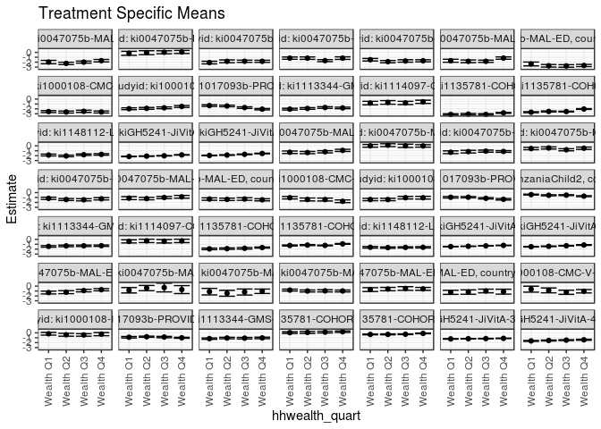

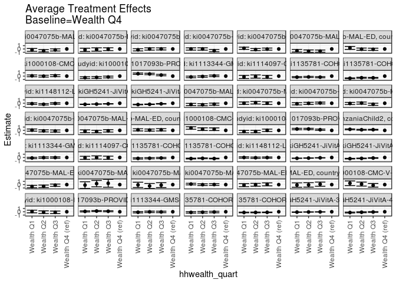

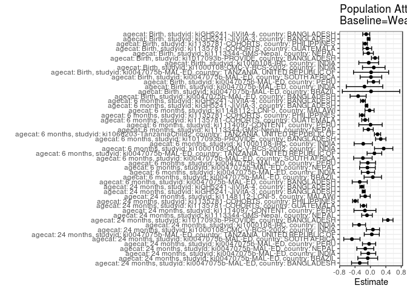

## Results Table

### Parameter: TSM

| agecat | studyid | country | intervention_level | baseline_level | estimate | ci_lower | ci_upper |
| --- | --- | --- | --- | --- | --- | --- | --- |
| Birth | ki0047075b-MAL-ED | BANGLADESH | Wealth Q4 | NA | -0.7338819 | -0.9623477 | -0.5054161 |
| Birth | ki0047075b-MAL-ED | BANGLADESH | Wealth Q1 | NA | -1.3171812 | -1.6002817 | -1.0340808 |
| Birth | ki0047075b-MAL-ED | BANGLADESH | Wealth Q2 | NA | -1.2374611 | -1.5408590 | -0.9340632 |
| Birth | ki0047075b-MAL-ED | BANGLADESH | Wealth Q3 | NA | -0.9128849 | -1.1746374 | -0.6511324 |
| Birth | ki0047075b-MAL-ED | BRAZIL | Wealth Q4 | NA | -0.7121747 | -1.5239437 | 0.0995943 |
| Birth | ki0047075b-MAL-ED | BRAZIL | Wealth Q1 | NA | -0.8531277 | -1.4037781 | -0.3024774 |
| Birth | ki0047075b-MAL-ED | BRAZIL | Wealth Q2 | NA | -0.3964385 | -0.9321489 | 0.1392719 |
| Birth | ki0047075b-MAL-ED | BRAZIL | Wealth Q3 | NA | -0.3005904 | -1.1863254 | 0.5851447 |
| Birth | ki0047075b-MAL-ED | INDIA | Wealth Q4 | NA | -1.0537500 | -1.5024873 | -0.6050127 |
| Birth | ki0047075b-MAL-ED | INDIA | Wealth Q1 | NA | -1.1307143 | -1.7957911 | -0.4656374 |
| Birth | ki0047075b-MAL-ED | INDIA | Wealth Q2 | NA | -1.4622222 | -2.0687425 | -0.8557019 |
| Birth | ki0047075b-MAL-ED | INDIA | Wealth Q3 | NA | -1.2070000 | -1.8208171 | -0.5931829 |
| Birth | ki0047075b-MAL-ED | PERU | Wealth Q4 | NA | -0.9928051 | -1.1822155 | -0.8033948 |
| Birth | ki0047075b-MAL-ED | PERU | Wealth Q1 | NA | -0.8145979 | -1.0068326 | -0.6223632 |
| Birth | ki0047075b-MAL-ED | PERU | Wealth Q2 | NA | -0.9985872 | -1.2048859 | -0.7922886 |
| Birth | ki0047075b-MAL-ED | PERU | Wealth Q3 | NA | -0.9651235 | -1.1852014 | -0.7450456 |
| Birth | ki0047075b-MAL-ED | SOUTH AFRICA | Wealth Q4 | NA | -0.5664441 | -0.8536667 | -0.2792214 |
| Birth | ki0047075b-MAL-ED | SOUTH AFRICA | Wealth Q1 | NA | -0.7137926 | -1.1020227 | -0.3255624 |
| Birth | ki0047075b-MAL-ED | SOUTH AFRICA | Wealth Q2 | NA | -0.6053114 | -0.9458790 | -0.2647438 |
| Birth | ki0047075b-MAL-ED | SOUTH AFRICA | Wealth Q3 | NA | -0.4877174 | -0.8613192 | -0.1141157 |
| Birth | ki0047075b-MAL-ED | TANZANIA, UNITED REPUBLIC OF | Wealth Q4 | NA | -1.1395810 | -1.6419148 | -0.6372473 |
| Birth | ki0047075b-MAL-ED | TANZANIA, UNITED REPUBLIC OF | Wealth Q1 | NA | -1.2679956 | -1.6901258 | -0.8458654 |
| Birth | ki0047075b-MAL-ED | TANZANIA, UNITED REPUBLIC OF | Wealth Q2 | NA | -1.2120531 | -1.6612229 | -0.7628834 |
| Birth | ki0047075b-MAL-ED | TANZANIA, UNITED REPUBLIC OF | Wealth Q3 | NA | -0.9935686 | -1.3654771 | -0.6216600 |
| Birth | ki1000108-CMC-V-BCS-2002 | INDIA | Wealth Q4 | NA | -1.0484941 | -1.3923916 | -0.7045967 |
| Birth | ki1000108-CMC-V-BCS-2002 | INDIA | Wealth Q1 | NA | -0.6282334 | -1.2417963 | -0.0146706 |
| Birth | ki1000108-CMC-V-BCS-2002 | INDIA | Wealth Q2 | NA | -0.8736986 | -1.3684091 | -0.3789882 |
| Birth | ki1000108-CMC-V-BCS-2002 | INDIA | Wealth Q3 | NA | -1.2576167 | -1.6834373 | -0.8317961 |
| Birth | ki1000108-IRC | INDIA | Wealth Q4 | NA | -0.2645257 | -0.5817355 | 0.0526840 |
| Birth | ki1000108-IRC | INDIA | Wealth Q1 | NA | -0.1866215 | -0.4637411 | 0.0904980 |

[output cut: 166 more lines]

### Parameter: E(Y)

| agecat | studyid | country | intervention_level | baseline_level | estimate | ci_lower | ci_upper |
| --- | --- | --- | --- | --- | --- | --- | --- |
| Birth | ki0047075b-MAL-ED | BANGLADESH | NA | NA | -1.0530516 | -1.1896058 | -0.9164975 |
| Birth | ki0047075b-MAL-ED | BRAZIL | NA | NA | -0.6963333 | -0.9881882 | -0.4044785 |
| Birth | ki0047075b-MAL-ED | INDIA | NA | NA | -1.2070732 | -1.5254820 | -0.8886644 |
| Birth | ki0047075b-MAL-ED | PERU | NA | NA | -0.9141395 | -1.0364098 | -0.7918693 |
| Birth | ki0047075b-MAL-ED | SOUTH AFRICA | NA | NA | -0.5523958 | -0.7550074 | -0.3497843 |
| Birth | ki0047075b-MAL-ED | TANZANIA, UNITED REPUBLIC OF | NA | NA | -1.1225000 | -1.3335666 | -0.9114334 |
| Birth | ki1000108-CMC-V-BCS-2002 | INDIA | NA | NA | -0.9611957 | -1.1776967 | -0.7446946 |
| Birth | ki1000108-IRC | INDIA | NA | NA | -0.3080412 | -0.4687931 | -0.1472894 |
| Birth | ki1017093b-PROVIDE | BANGLADESH | NA | NA | -0.8851020 | -0.9601332 | -0.8100709 |
| Birth | ki1113344-GMS-Nepal | NEPAL | NA | NA | -1.0851580 | -1.1651811 | -1.0051350 |
| Birth | ki1135781-COHORTS | GUATEMALA | NA | NA | 0.1452941 | 0.0610109 | 0.2295774 |
| Birth | ki1135781-COHORTS | PHILIPPINES | NA | NA | -0.2491505 | -0.2881717 | -0.2101294 |
| Birth | kiGH5241-JiVitA-3 | BANGLADESH | NA | NA | -1.1729995 | -1.2010694 | -1.1449297 |
| Birth | kiGH5241-JiVitA-4 | BANGLADESH | NA | NA | -1.5236135 | -1.5727559 | -1.4744711 |
| 6 months | ki0047075b-MAL-ED | BANGLADESH | NA | NA | -1.2031806 | -1.3209873 | -1.0853738 |
| 6 months | ki0047075b-MAL-ED | BRAZIL | NA | NA | 0.0510207 | -0.0930194 | 0.1950608 |
| 6 months | ki0047075b-MAL-ED | INDIA | NA | NA | -1.2069078 | -1.3255669 | -1.0882487 |
| 6 months | ki0047075b-MAL-ED | NEPAL | NA | NA | -0.5610593 | -0.6737915 | -0.4483272 |
| 6 months | ki0047075b-MAL-ED | PERU | NA | NA | -1.3293333 | -1.4383829 | -1.2202838 |
| 6 months | ki0047075b-MAL-ED | SOUTH AFRICA | NA | NA | -1.0554016 | -1.1850591 | -0.9257441 |
| 6 months | ki0047075b-MAL-ED | TANZANIA, UNITED REPUBLIC OF | NA | NA | -1.3687449 | -1.4907629 | -1.2467270 |
| 6 months | ki1000108-CMC-V-BCS-2002 | INDIA | NA | NA | -1.4234508 | -1.5645974 | -1.2823042 |
| 6 months | ki1000108-IRC | INDIA | NA | NA | -1.2344062 | -1.3658524 | -1.1029600 |
| 6 months | ki1017093b-PROVIDE | BANGLADESH | NA | NA | -1.0916915 | -1.1661176 | -1.0172654 |
| 6 months | ki1066203-TanzaniaChild2 | TANZANIA, UNITED REPUBLIC OF | NA | NA | -0.5442232 | -0.5932373 | -0.4952090 |
| 6 months | ki1113344-GMS-Nepal | NEPAL | NA | NA | -1.3508392 | -1.4290633 | -1.2726152 |
| 6 months | ki1114097-CONTENT | PERU | NA | NA | -0.3139217 | -0.4868486 | -0.1409948 |
| 6 months | ki1135781-COHORTS | GUATEMALA | NA | NA | -1.8112324 | -1.8807284 | -1.7417365 |
| 6 months | ki1135781-COHORTS | PHILIPPINES | NA | NA | -1.1405724 | -1.1824954 | -1.0986493 |
| 6 months | ki1148112-LCNI-5 | MALAWI | NA | NA | -1.6426961 | -1.7120603 | -1.5733318 |
| 6 months | kiGH5241-JiVitA-3 | BANGLADESH | NA | NA | -1.3357056 | -1.3587889 | -1.3126223 |
| 6 months | kiGH5241-JiVitA-4 | BANGLADESH | NA | NA | -1.3440477 | -1.3813060 | -1.3067894 |
| 24 months | ki0047075b-MAL-ED | BANGLADESH | NA | NA | -1.9789151 | -2.1055330 | -1.8522972 |
| 24 months | ki0047075b-MAL-ED | BRAZIL | NA | NA | 0.0071006 | -0.1615817 | 0.1757828 |
| 24 months | ki0047075b-MAL-ED | INDIA | NA | NA | -1.8848458 | -2.0096941 | -1.7599975 |
| 24 months | ki0047075b-MAL-ED | NEPAL | NA | NA | -1.3118640 | -1.4315132 | -1.1922149 |
| 24 months | ki0047075b-MAL-ED | PERU | NA | NA | -1.7544776 | -1.8753255 | -1.6336298 |
| 24 months | ki0047075b-MAL-ED | SOUTH AFRICA | NA | NA | -1.6491807 | -1.7842885 | -1.5140729 |
| 24 months | ki0047075b-MAL-ED | TANZANIA, UNITED REPUBLIC OF | NA | NA | -2.6451636 | -2.7802323 | -2.5100948 |
| 24 months | ki1000108-CMC-V-BCS-2002 | INDIA | NA | NA | -2.5588679 | -2.6583730 | -2.4593629 |
| 24 months | ki1000108-IRC | INDIA | NA | NA | -1.7987775 | -1.8923914 | -1.7051636 |
| 24 months | ki1017093b-PROVIDE | BANGLADESH | NA | NA | -1.6024221 | -1.6857420 | -1.5191023 |
| 24 months | ki1113344-GMS-Nepal | NEPAL | NA | NA | -1.8874180 | -1.9728588 | -1.8019773 |
| 24 months | ki1114097-CONTENT | PERU | NA | NA | -0.6962195 | -0.8674103 | -0.5250287 |
| 24 months | ki1135781-COHORTS | GUATEMALA | NA | NA | -2.9893430 | -3.0546993 | -2.9239867 |
| 24 months | ki1135781-COHORTS | PHILIPPINES | NA | NA | -2.4141145 | -2.4590818 | -2.3691473 |
| 24 months | ki1148112-LCNI-5 | MALAWI | NA | NA | -1.8822648 | -1.9637218 | -1.8008078 |
| 24 months | kiGH5241-JiVitA-3 | BANGLADESH | NA | NA | -2.0194951 | -2.0471365 | -1.9918537 |
| 24 months | kiGH5241-JiVitA-4 | BANGLADESH | NA | NA | -1.7803708 | -1.8158650 | -1.7448765 |

### Parameter: ATE

| agecat | studyid | country | intervention_level | baseline_level | estimate | ci_lower | ci_upper |
| --- | --- | --- | --- | --- | --- | --- | --- |
| Birth | ki0047075b-MAL-ED | BANGLADESH | Wealth Q4 | Wealth Q4 | 0.0000000 | 0.0000000 | 0.0000000 |
| Birth | ki0047075b-MAL-ED | BANGLADESH | Wealth Q1 | Wealth Q4 | -0.5832993 | -0.9474387 | -0.2191599 |
| Birth | ki0047075b-MAL-ED | BANGLADESH | Wealth Q2 | Wealth Q4 | -0.5035792 | -0.8822689 | -0.1248895 |
| Birth | ki0047075b-MAL-ED | BANGLADESH | Wealth Q3 | Wealth Q4 | -0.1790030 | -0.5251191 | 0.1671131 |
| Birth | ki0047075b-MAL-ED | BRAZIL | Wealth Q4 | Wealth Q4 | 0.0000000 | 0.0000000 | 0.0000000 |
| Birth | ki0047075b-MAL-ED | BRAZIL | Wealth Q1 | Wealth Q4 | -0.1409530 | -1.1414379 | 0.8595318 |
| Birth | ki0047075b-MAL-ED | BRAZIL | Wealth Q2 | Wealth Q4 | 0.3157362 | -0.6534505 | 1.2849229 |
| Birth | ki0047075b-MAL-ED | BRAZIL | Wealth Q3 | Wealth Q4 | 0.4115843 | -0.7832418 | 1.6064104 |
| Birth | ki0047075b-MAL-ED | INDIA | Wealth Q4 | Wealth Q4 | 0.0000000 | 0.0000000 | 0.0000000 |
| Birth | ki0047075b-MAL-ED | INDIA | Wealth Q1 | Wealth Q4 | -0.0769643 | -0.8792687 | 0.7253402 |
| Birth | ki0047075b-MAL-ED | INDIA | Wealth Q2 | Wealth Q4 | -0.4084722 | -1.1629469 | 0.3460025 |
| Birth | ki0047075b-MAL-ED | INDIA | Wealth Q3 | Wealth Q4 | -0.1532500 | -0.9136030 | 0.6071030 |
| Birth | ki0047075b-MAL-ED | PERU | Wealth Q4 | Wealth Q4 | 0.0000000 | 0.0000000 | 0.0000000 |
| Birth | ki0047075b-MAL-ED | PERU | Wealth Q1 | Wealth Q4 | 0.1782072 | -0.0711297 | 0.4275441 |
| Birth | ki0047075b-MAL-ED | PERU | Wealth Q2 | Wealth Q4 | -0.0057821 | -0.2641523 | 0.2525882 |
| Birth | ki0047075b-MAL-ED | PERU | Wealth Q3 | Wealth Q4 | 0.0276816 | -0.2403554 | 0.2957187 |
| Birth | ki0047075b-MAL-ED | SOUTH AFRICA | Wealth Q4 | Wealth Q4 | 0.0000000 | 0.0000000 | 0.0000000 |
| Birth | ki0047075b-MAL-ED | SOUTH AFRICA | Wealth Q1 | Wealth Q4 | -0.1473485 | -0.6088027 | 0.3141057 |
| Birth | ki0047075b-MAL-ED | SOUTH AFRICA | Wealth Q2 | Wealth Q4 | -0.0388673 | -0.4702922 | 0.3925576 |
| Birth | ki0047075b-MAL-ED | SOUTH AFRICA | Wealth Q3 | Wealth Q4 | 0.0787266 | -0.3732853 | 0.5307386 |
| Birth | ki0047075b-MAL-ED | TANZANIA, UNITED REPUBLIC OF | Wealth Q4 | Wealth Q4 | 0.0000000 | 0.0000000 | 0.0000000 |
| Birth | ki0047075b-MAL-ED | TANZANIA, UNITED REPUBLIC OF | Wealth Q1 | Wealth Q4 | -0.1284145 | -0.7926070 | 0.5357780 |
| Birth | ki0047075b-MAL-ED | TANZANIA, UNITED REPUBLIC OF | Wealth Q2 | Wealth Q4 | -0.0724721 | -0.7578702 | 0.6129261 |
| Birth | ki0047075b-MAL-ED | TANZANIA, UNITED REPUBLIC OF | Wealth Q3 | Wealth Q4 | 0.1460125 | -0.4810875 | 0.7731124 |
| Birth | ki1000108-CMC-V-BCS-2002 | INDIA | Wealth Q4 | Wealth Q4 | 0.0000000 | 0.0000000 | 0.0000000 |
| Birth | ki1000108-CMC-V-BCS-2002 | INDIA | Wealth Q1 | Wealth Q4 | 0.4202607 | -0.2860329 | 1.1265544 |
| Birth | ki1000108-CMC-V-BCS-2002 | INDIA | Wealth Q2 | Wealth Q4 | 0.1747955 | -0.4298103 | 0.7794013 |
| Birth | ki1000108-CMC-V-BCS-2002 | INDIA | Wealth Q3 | Wealth Q4 | -0.2091226 | -0.7579077 | 0.3396626 |
| Birth | ki1000108-IRC | INDIA | Wealth Q4 | Wealth Q4 | 0.0000000 | 0.0000000 | 0.0000000 |
| Birth | ki1000108-IRC | INDIA | Wealth Q1 | Wealth Q4 | 0.0779042 | -0.3226191 | 0.4784275 |

[output cut: 166 more lines]

### Parameter: PAR

| agecat | studyid | country | intervention_level | baseline_level | estimate | ci_lower | ci_upper |
| --- | --- | --- | --- | --- | --- | --- | --- |
| Birth | ki0047075b-MAL-ED | BANGLADESH | Wealth Q4 | NA | -0.3191697 | -0.5277101 | -0.1106294 |
| Birth | ki0047075b-MAL-ED | BRAZIL | Wealth Q4 | NA | 0.0158414 | -0.7289451 | 0.7606278 |
| Birth | ki0047075b-MAL-ED | INDIA | Wealth Q4 | NA | -0.1533232 | -0.6267868 | 0.3201405 |
| Birth | ki0047075b-MAL-ED | PERU | Wealth Q4 | NA | 0.0786656 | -0.0770577 | 0.2343889 |
| Birth | ki0047075b-MAL-ED | SOUTH AFRICA | Wealth Q4 | NA | 0.0140482 | -0.2667700 | 0.2948665 |
| Birth | ki0047075b-MAL-ED | TANZANIA, UNITED REPUBLIC OF | Wealth Q4 | NA | 0.0170810 | -0.4389572 | 0.4731193 |
| Birth | ki1000108-CMC-V-BCS-2002 | INDIA | Wealth Q4 | NA | 0.0872985 | -0.2055361 | 0.3801331 |
| Birth | ki1000108-IRC | INDIA | Wealth Q4 | NA | -0.0435155 | -0.3007845 | 0.2137535 |
| Birth | ki1017093b-PROVIDE | BANGLADESH | Wealth Q4 | NA | 0.1206950 | 0.0283923 | 0.2129977 |
| Birth | ki1113344-GMS-Nepal | NEPAL | Wealth Q4 | NA | -0.0552801 | -0.1870587 | 0.0764985 |
| Birth | ki1135781-COHORTS | GUATEMALA | Wealth Q4 | NA | -0.0807150 | -0.1945625 | 0.0331325 |
| Birth | ki1135781-COHORTS | PHILIPPINES | Wealth Q4 | NA | -0.1357943 | -0.1933494 | -0.0782391 |
| Birth | kiGH5241-JiVitA-3 | BANGLADESH | Wealth Q4 | NA | -0.0476940 | -0.0811092 | -0.0142789 |
| Birth | kiGH5241-JiVitA-4 | BANGLADESH | Wealth Q4 | NA | -0.1093338 | -0.1999950 | -0.0186727 |
| 6 months | ki0047075b-MAL-ED | BANGLADESH | Wealth Q4 | NA | -0.2776715 | -0.4731528 | -0.0821902 |
| 6 months | ki0047075b-MAL-ED | BRAZIL | Wealth Q4 | NA | 0.0623774 | -0.1639889 | 0.2887438 |
| 6 months | ki0047075b-MAL-ED | INDIA | Wealth Q4 | NA | -0.0628256 | -0.2349427 | 0.1092915 |
| 6 months | ki0047075b-MAL-ED | NEPAL | Wealth Q4 | NA | -0.0774877 | -0.2814221 | 0.1264466 |
| 6 months | ki0047075b-MAL-ED | PERU | Wealth Q4 | NA | -0.0682580 | -0.2697485 | 0.1332324 |
| 6 months | ki0047075b-MAL-ED | SOUTH AFRICA | Wealth Q4 | NA | -0.1953198 | -0.4355013 | 0.0448617 |
| 6 months | ki0047075b-MAL-ED | TANZANIA, UNITED REPUBLIC OF | Wealth Q4 | NA | 0.1039345 | -0.0864496 | 0.2943186 |
| 6 months | ki1000108-CMC-V-BCS-2002 | INDIA | Wealth Q4 | NA | 0.3446012 | 0.1066629 | 0.5825395 |
| 6 months | ki1000108-IRC | INDIA | Wealth Q4 | NA | -0.1865981 | -0.4237118 | 0.0505156 |
| 6 months | ki1017093b-PROVIDE | BANGLADESH | Wealth Q4 | NA | 0.2682793 | 0.1336466 | 0.4029121 |
| 6 months | ki1066203-TanzaniaChild2 | TANZANIA, UNITED REPUBLIC OF | Wealth Q4 | NA | 0.1845012 | 0.1033915 | 0.2656108 |
| 6 months | ki1113344-GMS-Nepal | NEPAL | Wealth Q4 | NA | -0.0552989 | -0.1838714 | 0.0732735 |
| 6 months | ki1114097-CONTENT | PERU | Wealth Q4 | NA | 0.0027951 | -0.3004629 | 0.3060531 |
| 6 months | ki1135781-COHORTS | GUATEMALA | Wealth Q4 | NA | -0.1366449 | -0.2249786 | -0.0483112 |
| 6 months | ki1135781-COHORTS | PHILIPPINES | Wealth Q4 | NA | -0.2165625 | -0.2854819 | -0.1476431 |
| 6 months | ki1148112-LCNI-5 | MALAWI | Wealth Q4 | NA | -0.0231312 | -0.1413499 | 0.0950874 |
| 6 months | kiGH5241-JiVitA-3 | BANGLADESH | Wealth Q4 | NA | -0.1002045 | -0.1307039 | -0.0697052 |
| 6 months | kiGH5241-JiVitA-4 | BANGLADESH | Wealth Q4 | NA | -0.1933202 | -0.2564482 | -0.1301922 |
| 24 months | ki0047075b-MAL-ED | BANGLADESH | Wealth Q4 | NA | -0.2776374 | -0.4902299 | -0.0650448 |
| 24 months | ki0047075b-MAL-ED | BRAZIL | Wealth Q4 | NA | -0.0694167 | -0.3267641 | 0.1879307 |
| 24 months | ki0047075b-MAL-ED | INDIA | Wealth Q4 | NA | -0.0542337 | -0.2470140 | 0.1385466 |
| 24 months | ki0047075b-MAL-ED | NEPAL | Wealth Q4 | NA | -0.1333045 | -0.3529340 | 0.0863250 |
| 24 months | ki0047075b-MAL-ED | PERU | Wealth Q4 | NA | -0.0348066 | -0.2063743 | 0.1367611 |
| 24 months | ki0047075b-MAL-ED | SOUTH AFRICA | Wealth Q4 | NA | -0.4810593 | -0.6923848 | -0.2697339 |
| 24 months | ki0047075b-MAL-ED | TANZANIA, UNITED REPUBLIC OF | Wealth Q4 | NA | 0.0356803 | -0.1601671 | 0.2315278 |
| 24 months | ki1000108-CMC-V-BCS-2002 | INDIA | Wealth Q4 | NA | 0.0653806 | -0.1055542 | 0.2363153 |
| 24 months | ki1000108-IRC | INDIA | Wealth Q4 | NA | -0.2928913 | -0.4597528 | -0.1260298 |
| 24 months | ki1017093b-PROVIDE | BANGLADESH | Wealth Q4 | NA | 0.4523075 | 0.3168129 | 0.5878020 |
| 24 months | ki1113344-GMS-Nepal | NEPAL | Wealth Q4 | NA | -0.0889511 | -0.2262244 | 0.0483222 |
| 24 months | ki1114097-CONTENT | PERU | Wealth Q4 | NA | -0.1422094 | -0.4277656 | 0.1433468 |
| 24 months | ki1135781-COHORTS | GUATEMALA | Wealth Q4 | NA | -0.1789964 | -0.2587303 | -0.0992625 |
| 24 months | ki1135781-COHORTS | PHILIPPINES | Wealth Q4 | NA | -0.3932151 | -0.4636897 | -0.3227406 |
| 24 months | ki1148112-LCNI-5 | MALAWI | Wealth Q4 | NA | -0.1368214 | -0.2674221 | -0.0062207 |
| 24 months | kiGH5241-JiVitA-3 | BANGLADESH | Wealth Q4 | NA | -0.1744180 | -0.2127125 | -0.1361235 |
| 24 months | kiGH5241-JiVitA-4 | BANGLADESH | Wealth Q4 | NA | -0.2214624 | -0.2744701 | -0.1684547 |